# Data Visualization and Dimensional reduction

This R Markdown file contains code, output, and narrative text for analysis using the `SingleCellExperiment` class in R.

- To view the results directly, open the rendered HTML file (`.html`) in a browser.
- To reproduce or modify the analysis, open this `.Rmd` file in [RStudio](https://posit.co/downloads/).
- You can knit this file to HTML using the **Knit** button or with `rmarkdown::render("filename.Rmd")`.

This file is part of a reproducible analysis workflow.

Loading required packages

```r
#BiocManager::install("AnnotationDbi")
#BiocManager::install("org.Hs.eg.db", "EnsDb.Hsapiens.v86", "SingleCellExperiment","scater")
library(scater)
library(SingleCellExperiment)
library(AnnotationDbi)
library(org.Hs.eg.db)
library(EnsDb.Hsapiens.v86)
library(scales)

#load the created umi data
umi<-readRDS("Data/tung/umi.rds")
```

### 1. Introduction

This section provides different ways of visualizing the data to allow you to asses what happened to the expression matrix after the quality control step. scater package provides several very useful functions to simplify visualisation.

One important aspect of single-cell RNA-seq is to control for batch effects. **Batch effects** are technical artefacts that are added to the samples during handling. For example, if two sets of samples were prepared in different labs or even on different days in the same lab, then we may observe greater similarities between the samples that were handled together. In the worst case scenario, batch effects may be mistaken for true biological variation. The Tung data allows us to explore these issues in a controlled manner since some of the salient aspects of how the samples were handled have been recorded. Ideally, we expect to see batches from the same individual grouping together and distinct groups corresponding to each individual.

```r
#Creating another SingleCellExperiment object, umi.qc, in which remove unnecessary poorly expressed genes and low quality cells
umi.qc <- umi[! rowData(umi)$discard,! colData(umi)$discard]
```

### 2. PCA plot

When we look at single-cell RNA-seq data, each cell has thousands of gene measurements, which is difficult to analyse. Principal Component Analysis (PCA) helps simplify this by:

- Reducing the number of dimensions (genes) while keeping most of the important information.
- Showing us the main patterns or differences between the cells in just a few summary “directions” called principal components (PCs).

#### 2.1 PCA before QC

Running a PCA before and after log normalization impacts its ability to group cells via individuals and replicates. Hence along with the log normalization we have to consider library size normalization (sequencing depth such as cpm/tpm etc..).

```r
# PCA on Raw Counts (Before Normalization/QC), runs PCA using raw count data (not transformed or normalized). However, cells with high RNA content or highly expressed genes dominate the result — not good for interpretation

umi <- runPCA(umi, exprs_values = "counts")
dim(reducedDim(umi, "PCA"))
```

```
## [1] 864  50
```

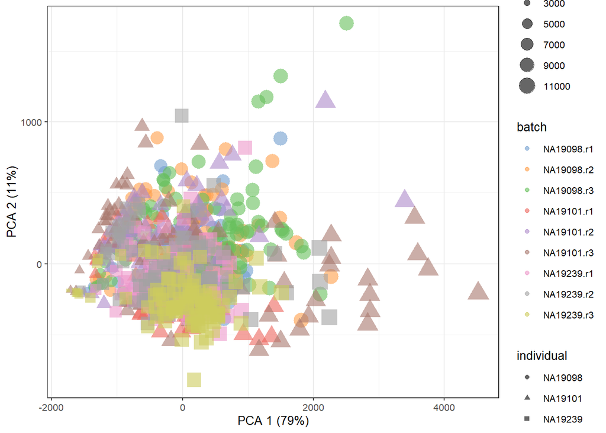

```r
#PCA has created a matrix with 864 cells and 50 principal components. Each PC captures a direction of variation; PC1 explains the most.

#Plots the PCA result: The color shows different sequencing batches, dot size represents how many genes were detected per cell, each point’s shape reflects the individual/sample.

#Clustering or separation of cells by batch or individual should happen. With raw counts, this usually doesn’t happen — instead, sequencing depth dominates.

plotPCA(umi, colour_by = "batch", size_by = "detected", shape_by = "individual")
```

```r
#PCA After Log-Transformation

#Re-run PCA, now using log-transformed counts (log2(counts + 1)). This makes high values less extreme, improving visibility of true biological differences.

umi <- runPCA(umi, exprs_values = "logcounts_raw")

dim(reducedDim(umi, "PCA")) #reducedDim object in umi is overwritten.
```

```
## [1] 864  50
```

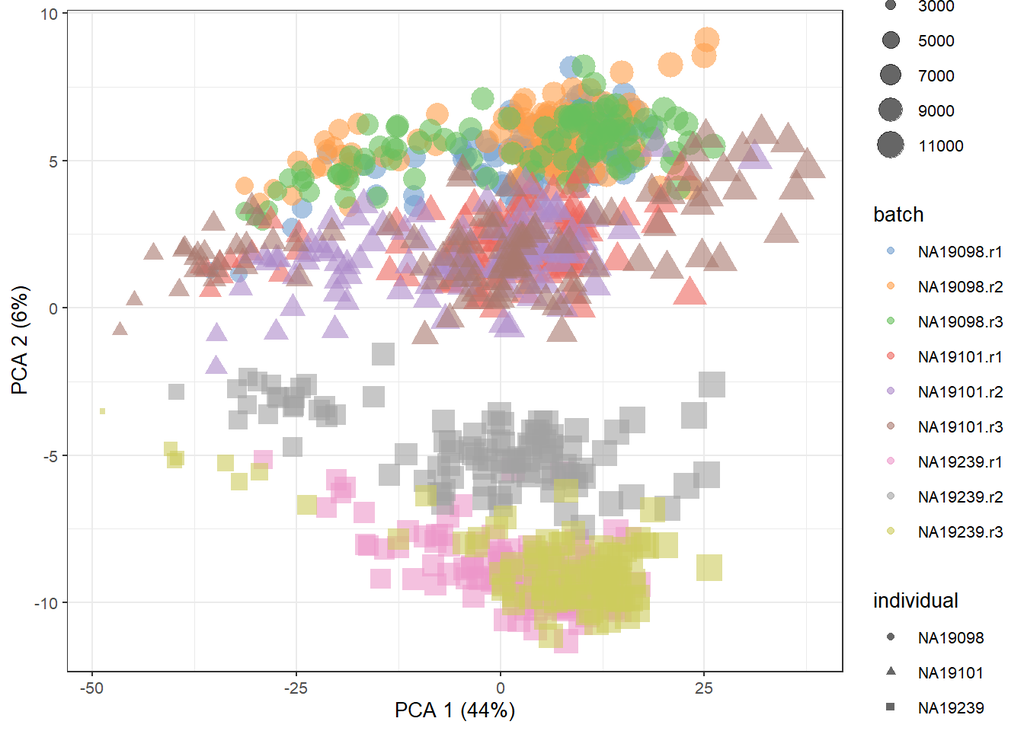

```r
## PCA was recalculated — same number of cells, new PCs.

#A similar PCA plot, but now PCA is more meaningful.Clearer grouping by batch or sample is seen and hence log transformation has helped!
plotPCA(umi, colour_by = "batch", size_by = "detected", shape_by = "individual")
```

```r
#However, log normalization is not enough we have to use library-size normalization as well for downstream analysis.
```